# (Big) Data Analytics for Business

## Segmentation in the Boating Industry

T. Evgeniou and J. Niessing  
INSEAD

## Every factor analysis has three basic decision points

Decide the number of factors

Choose an extraction method

Choose a rotation method

## Correlation matrix of the 29 attitudes as a pre-step

|  | Q1_1_When buying a boat, I do a lot of shopping around and visit multiple dealers | Q1_2_When buying a boat, getting the lowest price is more important than the boat brand | Q1_3_The brand of boat I buy says a lot about who I am | Q1_4_I only consider buying a boat from a reputable brand | Q1_5_I am willing to pay a premium for a brand with a reputation for high quality | Q1_6_Owning a boat is a way of rewarding myself for my hard work | Q1_7_Owning a boat gives me a sense of achievement | Q1_8_When buying a boat, functionality is more important than style | Q1_9_I see my boat as a status symbol | Q1_10_When buying a boat, I rely more on expert opinion than my own (e.g. consumer reports, salespeople) | Q1_11_I tend to perform minor boat repairs and maintenance on my own | Q1_12_When it comes to boating, I tend to prefer a basic boat with little to no frills | Q1_13_When buying a boat, I tend to buy the latest and greatest | Q1_14_When buying accessories for my boat, I tend to buy the latest and greatest | Q1_15_I am serious about the technology on my boat | Q1_16_People tend to come to me for advice about boating | Q1_17_I consider myself more knowledgeable about boating than the rest of my boating peers | Q1_18_Boating gives me a feeling of adventure | Q1_19_Boating allows me to experience nature | Q1_20_When not on my boat, I often find myself doing boating related activities | Q1_21_Boating helps me escape from everyday life and relax | Q1_22_Boating helps me stay active | Q1_23_Boating allows me to excel in the sports that I am passionate about (e.g. fishing, racing, water sports) | Q1_24_Boating gives me an outlet to socialize with family and/or friends | Q1_25_Being in charge of my boat is very important to me | Q1_26_Having a powerful boat is what is most important to me | Q1_27_Boating is the number one thing I do with my spare time | Q1_28_Boating is my true passion in life | Q1_29_Boating is one of many things I do in my spare time |
| --- | --- | --- | --- | --- | --- | --- | --- | --- | --- | --- | --- | --- | --- | --- | --- | --- | --- | --- | --- | --- | --- | --- | --- | --- | --- | --- | --- | --- | --- |
| Q1_1_When buying a boat, I do a lot of shopping around and visit multiple dealers | 1.00 | 0.008983 | 0.1075 | 0.1983 | 0.1835 | 0.2678 | 0.1846 | 0.08861 | 0.0778 | 0.1071 | 0.1449 | -0.05305 | 0.1225 | 0.1785 | 0.2611 | 0.1572 | 0.1478 | 0.2533 | 0.274 | 0.1941 | 0.2353 | 0.2315 | 0.1876 | 0.2091 | 0.2271 | 0.1038 | 0.1268 | 0.176 | 0.2016 |
| Q1_2_When buying a boat, getting the lowest price is more important than the boat brand | 0.008983 | 1.00 | -0.02956 | -0.2101 | -0.2058 | -0.03727 | 0.02025 | 0.1967 | 0.08722 | 0.1583 | 0.04285 | 0.3702 | 0.006216 | -0.03048 | -0.07769 | -0.01528 | 0.03892 | -0.03771 | -0.03631 | 0.05335 | -0.09945 | -0.07645 | 0.002847 | -0.0755 | 0.008886 | 0.0738 | 0.04546 | 0.01602 | -0.02895 |
| Q1_3_The brand of boat I buy says a lot about who I am | 0.1075 | -0.02956 | 1.00 | 0.2636 | 0.3997 | 0.3401 | 0.4436 | -0.05102 | 0.5789 | 0.1356 | 0.09649 | -0.08893 | 0.4845 | 0.4615 | 0.3762 | 0.3872 | 0.379 | 0.2379 | 0.1414 | 0.3856 | 0.182 | 0.2814 | 0.3396 | 0.2277 | 0.358 | 0.471 | 0.4008 | 0.4253 | 0.1659 |
| Q1_4_I only consider buying a boat from a reputable brand | 0.1983 | -0.2101 | 0.2636 | 1.00 | 0.3667 | 0.2015 | 0.1753 | 0.003764 | 0.1676 | 0.1001 | 0.0588 | -0.1598 | 0.2727 | 0.2941 | 0.2961 | 0.1821 | 0.1749 | 0.1845 | 0.1855 | 0.1833 | 0.183 | 0.2335 | 0.1642 | 0.2291 | 0.218 | 0.1923 | 0.165 | 0.2124 | 0.1865 |
| Q1_5_I am willing to pay a premium for a brand with a reputation for high quality | 0.1835 | -0.2058 | 0.3997 | 0.3667 | 1.00 | 0.2929 | 0.2854 | -0.03322 | 0.3287 | 0.1357 | 0.06923 | -0.1725 | 0.4504 | 0.4599 | 0.4176 | 0.3553 | 0.3184 | 0.2342 | 0.1842 | 0.3229 | 0.1873 | 0.2737 | 0.2934 | 0.2492 | 0.2903 | 0.3372 | 0.294 | 0.325 | 0.1778 |
| Q1_6_Owning a boat is a way of rewarding myself for my hard work | 0.2678 | -0.03727 | 0.3401 | 0.2015 | 0.2929 | 1.00 | 0.546 | 0.04036 | 0.3489 | 0.1245 | 0.1461 | -0.1154 | 0.2857 | 0.3138 | 0.3143 | 0.2718 | 0.2362 | 0.4375 | 0.3555 | 0.354 | 0.4242 | 0.4088 | 0.3179 | 0.367 | 0.42 | 0.3074 | 0.3447 | 0.3924 | 0.2715 |
| Q1_7_Owning a boat gives me a sense of achievement | 0.1846 | 0.02025 | 0.4436 | 0.1753 | 0.2854 | 0.546 | 1.00 | -0.005651 | 0.4908 | 0.1217 | 0.1152 | -0.1091 | 0.3489 | 0.3619 | 0.3449 | 0.3091 | 0.2852 | 0.4009 | 0.2815 | 0.3633 | 0.3274 | 0.3902 | 0.3044 | 0.3328 | 0.4194 | 0.3865 | 0.3706 | 0.3994 | 0.2406 |
| Q1_8_When buying a boat, functionality is more important than style | 0.08861 | 0.1967 | -0.05102 | 0.003764 | -0.03322 | 0.04036 | -0.005651 | 1.00 | -0.09188 | 0.08512 | 0.1426 | 0.2354 | -0.04788 | -0.02173 | 0.06132 | 0.02284 | 0.04813 | 0.07381 | 0.09498 | 0.04331 | 0.06314 | 0.05412 | 0.09931 | 0.0186 | 0.09906 | -0.04454 | 0.0292 | 0.04579 | 0.09732 |
| Q1_9_I see my boat as a status symbol | 0.0778 | 0.08722 | 0.5789 | 0.1676 | 0.3287 | 0.3489 | 0.4908 | -0.09188 | 1.00 | 0.143 | 0.05987 | -0.04386 | 0.4801 | 0.4267 | 0.3327 | 0.3892 | 0.3656 | 0.218 | 0.0744 | 0.3659 | 0.1435 | 0.2325 | 0.2887 | 0.2304 | 0.3191 | 0.5027 | 0.3997 | 0.4025 | 0.1147 |
| Q1_10_When buying a boat, I rely more on expert opinion than my own (e.g. consumer reports, salespeople) | 0.1071 | 0.1583 | 0.1356 | 0.1001 | 0.1357 | 0.1245 | 0.1217 | 0.08512 | 0.143 | 1.00 | -0.08855 | 0.1223 | 0.1614 | 0.1051 | 0.1111 | -0.03012 | -0.02844 | 0.1406 | 0.09459 | 0.09628 | 0.07687 | 0.09113 | 0.06955 | 0.1312 | 0.07601 | 0.1348 | 0.07711 | 0.06922 | 0.05107 |
| Q1_11_I tend to perform minor boat repairs and maintenance on my own | 0.1449 | 0.04285 | 0.09649 | 0.0588 | 0.06923 | 0.1461 | 0.1152 | 0.1426 | 0.05987 | -0.08855 | 1.00 | 0.08748 | 0.07991 | 0.1345 | 0.205 | 0.3192 | 0.308 | 0.1119 | 0.1233 | 0.25 | 0.1291 | 0.1701 | 0.1921 | 0.0773 | 0.2489 | 0.09386 | 0.157 | 0.1829 | 0.1659 |
| Q1_12_When it comes to boating, I tend to prefer a basic boat with little to no frills | -0.05305 | 0.3702 | -0.08893 | -0.1598 | -0.1725 | -0.1154 | -0.1091 | 0.2354 | -0.04386 | 0.1223 | 0.08748 | 1.00 | -0.1131 | -0.1652 | -0.1677 | -0.02316 | 0.01641 | -0.1194 | -0.09364 | 0.008689 | -0.1682 | -0.1144 | -0.03205 | -0.1693 | -0.0547 | -0.06386 | 0.002133 | -0.009516 | -0.03549 |
| Q1_13_When buying a boat, I tend to buy the latest and greatest | 0.1225 | 0.006216 | 0.4845 | 0.2727 | 0.4504 | 0.2857 | 0.3489 | -0.04788 | 0.4801 | 0.1614 | 0.07991 | -0.1131 | 1.00 | 0.6382 | 0.4577 | 0.4271 | 0.4259 | 0.2035 | 0.1111 | 0.3868 | 0.1354 | 0.2301 | 0.3187 | 0.1963 | 0.3234 | 0.481 | 0.3981 | 0.4041 | 0.1903 |
| Q1_14_When buying accessories for my boat, I tend to buy the latest and greatest | 0.1785 | -0.03048 | 0.4615 | 0.2941 | 0.4599 | 0.3138 | 0.3619 | -0.02173 | 0.4267 | 0.1051 | 0.1345 | -0.1652 | 0.6382 | 1.00 | 0.4999 | 0.4272 | 0.3976 | 0.2493 | 0.1773 | 0.4065 | 0.2082 | 0.2852 | 0.3565 | 0.209 | 0.3533 | 0.4649 | 0.3934 | 0.4049 | 0.2109 |
| Q1_15_I am serious about the technology on my boat | 0.2611 | -0.07769 | 0.3762 | 0.2961 | 0.4176 | 0.3143 | 0.3449 | 0.06132 | 0.3327 | 0.1111 | 0.205 | -0.1677 | 0.4577 | 0.4999 | 1.00 | 0.4117 | 0.3943 | 0.3164 | 0.2634 | 0.407 | 0.21 | 0.3264 | 0.353 | 0.2655 | 0.428 | 0.3732 | 0.3504 | 0.3784 | 0.2449 |
| Q1_16_People tend to come to me for advice about boating | 0.1572 | -0.01528 | 0.3872 | 0.1821 | 0.3553 | 0.2718 | 0.3091 | 0.02284 | 0.3892 | -0.03012 | 0.3192 | -0.02316 | 0.4271 | 0.4272 | 0.4117 | 1.00 | 0.6314 | 0.2029 | 0.138 | 0.5216 | 0.1584 | 0.30 | 0.3996 | 0.1941 | 0.3858 | 0.402 | 0.4758 | 0.4964 | 0.202 |
| Q1_17_I consider myself more knowledgeable about boating than the rest of my boating peers | 0.1478 | 0.03892 | 0.379 | 0.1749 | 0.3184 | 0.2362 | 0.2852 | 0.04813 | 0.3656 | -0.02844 | 0.308 | 0.01641 | 0.4259 | 0.3976 | 0.3943 | 0.6314 | 1.00 | 0.1709 | 0.1219 | 0.4456 | 0.1255 | 0.2584 | 0.3631 | 0.1486 | 0.3624 | 0.3981 | 0.4379 | 0.4625 | 0.2094 |
| Q1_18_Boating gives me a feeling of adventure | 0.2533 | -0.03771 | 0.2379 | 0.1845 | 0.2342 | 0.4375 | 0.4009 | 0.07381 | 0.218 | 0.1406 | 0.1119 | -0.1194 | 0.2035 | 0.2493 | 0.3164 | 0.2029 | 0.1709 | 1.00 | 0.4873 | 0.2811 | 0.4728 | 0.437 | 0.2903 | 0.4227 | 0.3722 | 0.2386 | 0.2467 | 0.3128 | 0.2992 |
| Q1_19_Boating allows me to experience nature | 0.274 | -0.03631 | 0.1414 | 0.1855 | 0.1842 | 0.3555 | 0.2815 | 0.09498 | 0.0744 | 0.09459 | 0.1233 | -0.09364 | 0.1111 | 0.1773 | 0.2634 | 0.138 | 0.1219 | 0.4873 | 1.00 | 0.213 | 0.44 | 0.38 | 0.2436 | 0.3658 | 0.3239 | 0.1394 | 0.1756 | 0.232 | 0.2788 |
| Q1_20_When not on my boat, I often find myself doing boating related activities | 0.1941 | 0.05335 | 0.3856 | 0.1833 | 0.3229 | 0.354 | 0.3633 | 0.04331 | 0.3659 | 0.09628 | 0.25 | 0.008689 | 0.3868 | 0.4065 | 0.407 | 0.5216 | 0.4456 | 0.2811 | 0.213 | 1.00 | 0.2258 | 0.3346 | 0.4045 | 0.2375 | 0.4056 | 0.4034 | 0.5033 | 0.5203 | 0.2473 |
| Q1_21_Boating helps me escape from everyday life and relax | 0.2353 | -0.09945 | 0.182 | 0.183 | 0.1873 | 0.4242 | 0.3274 | 0.06314 | 0.1435 | 0.07687 | 0.1291 | -0.1682 | 0.1354 | 0.2082 | 0.21 | 0.1584 | 0.1255 | 0.4728 | 0.44 | 0.2258 | 1.00 | 0.4212 | 0.2391 | 0.4242 | 0.3022 | 0.1478 | 0.2356 | 0.2604 | 0.2943 |
| Q1_22_Boating helps me stay active | 0.2315 | -0.07645 | 0.2814 | 0.2335 | 0.2737 | 0.4088 | 0.3902 | 0.05412 | 0.2325 | 0.09113 | 0.1701 | -0.1144 | 0.2301 | 0.2852 | 0.3264 | 0.30 | 0.2584 | 0.437 | 0.38 | 0.3346 | 0.4212 | 1.00 | 0.3368 | 0.3828 | 0.3662 | 0.232 | 0.3458 | 0.3756 | 0.3412 |
| Q1_23_Boating allows me to excel in the sports that I am passionate about (e.g. fishing, racing, water sports) | 0.1876 | 0.002847 | 0.3396 | 0.1642 | 0.2934 | 0.3179 | 0.3044 | 0.09931 | 0.2887 | 0.06955 | 0.1921 | -0.03205 | 0.3187 | 0.3565 | 0.353 | 0.3996 | 0.3631 | 0.2903 | 0.2436 | 0.4045 | 0.2391 | 0.3368 | 1.00 | 0.2303 | 0.3238 | 0.331 | 0.3904 | 0.4386 | 0.2344 |
| Q1_24_Boating gives me an outlet to socialize with family and/or friends | 0.2091 | -0.0755 | 0.2277 | 0.2291 | 0.2492 | 0.367 | 0.3328 | 0.0186 | 0.2304 | 0.1312 | 0.0773 | -0.1693 | 0.1963 | 0.209 | 0.2655 | 0.1941 | 0.1486 | 0.4227 | 0.3658 | 0.2375 | 0.4242 | 0.3828 | 0.2303 | 1.00 | 0.3058 | 0.2051 | 0.2442 | 0.2547 | 0.2713 |
| Q1_25_Being in charge of my boat is very important to me | 0.2271 | 0.008886 | 0.358 | 0.218 | 0.2903 | 0.42 | 0.4194 | 0.09906 | 0.3191 | 0.07601 | 0.2489 | -0.0547 | 0.3234 | 0.3533 | 0.428 | 0.3858 | 0.3624 | 0.3722 | 0.3239 | 0.4056 | 0.3022 | 0.3662 | 0.3238 | 0.3058 | 1.00 | 0.3364 | 0.3532 | 0.4013 | 0.2334 |
| Q1_26_Having a powerful boat is what is most important to me | 0.1038 | 0.0738 | 0.471 | 0.1923 | 0.3372 | 0.3074 | 0.3865 | -0.04454 | 0.5027 | 0.1348 | 0.09386 | -0.06386 | 0.481 | 0.4649 | 0.3732 | 0.402 | 0.3981 | 0.2386 | 0.1394 | 0.4034 | 0.1478 | 0.232 | 0.331 | 0.2051 | 0.3364 | 1.00 | 0.4504 | 0.4729 | 0.1499 |
| Q1_27_Boating is the number one thing I do with my spare time | 0.1268 | 0.04546 | 0.4008 | 0.165 | 0.294 | 0.3447 | 0.3706 | 0.0292 | 0.3997 | 0.07711 | 0.157 | 0.002133 | 0.3981 | 0.3934 | 0.3504 | 0.4758 | 0.4379 | 0.2467 | 0.1756 | 0.5033 | 0.2356 | 0.3458 | 0.3904 | 0.2442 | 0.3532 | 0.4504 | 1.00 | 0.6153 | 0.2336 |
| Q1_28_Boating is my true passion in life | 0.176 | 0.01602 | 0.4253 | 0.2124 | 0.325 | 0.3924 | 0.3994 | 0.04579 | 0.4025 | 0.06922 | 0.1829 | -0.009516 | 0.4041 | 0.4049 | 0.3784 | 0.4964 | 0.4625 | 0.3128 | 0.232 | 0.5203 | 0.2604 | 0.3756 | 0.4386 | 0.2547 | 0.4013 | 0.4729 | 0.6153 | 1.00 | 0.2608 |
| Q1_29_Boating is one of many things I do in my spare time | 0.2016 | -0.02895 | 0.1659 | 0.1865 | 0.1778 | 0.2715 | 0.2406 | 0.09732 | 0.1147 | 0.05107 | 0.1659 | -0.03549 | 0.1903 | 0.2109 | 0.2449 | 0.202 | 0.2094 | 0.2992 | 0.2788 | 0.2473 | 0.2943 | 0.3412 | 0.2344 | 0.2713 | 0.2334 | 0.1499 | 0.2336 | 0.2608 | 1.00 |

## Number of Factors

There are three commen ways to select the number of factors:

1. All factors with eigenvalue larger than 1
2. Based on the cumulative variance we would like to explain (e.g. at least 50% for example).
3. Pick the number of factrors corresponding to the "elbow" of the scree plot

The first two approaches to select the number of factors/derived variables are based on statistical criteria and can be seen in the following table:

## Eigenvalues and explained variance

Eigenvalues and Variance Explained

|  | eigenvalue | percentage of variance | cumulative percentage of variance |
| --- | --- | --- | --- |
| comp 1 | 8.433 | 29.078 | 29.078 |
| comp 2 | 2.334 | 8.047 | 37.125 |
| comp 3 | 1.863 | 6.423 | 43.548 |
| comp 4 | 1.458 | 5.026 | 48.574 |
| comp 5 | 1.207 | 4.163 | 52.738 |
| comp 6 | 0.898 | 3.098 | 55.835 |
| comp 7 | 0.817 | 2.816 | 58.652 |
| comp 8 | 0.786 | 2.712 | 61.363 |
| comp 9 | 0.780 | 2.691 | 64.054 |
| comp 10 | 0.741 | 2.556 | 66.611 |
| comp 11 | 0.687 | 2.368 | 68.978 |
| comp 12 | 0.654 | 2.254 | 71.232 |
| comp 13 | 0.648 | 2.234 | 73.467 |
| comp 14 | 0.618 | 2.131 | 75.598 |
| comp 15 | 0.609 | 2.100 | 77.698 |
| comp 16 | 0.576 | 1.988 | 79.686 |
| comp 17 | 0.562 | 1.937 | 81.623 |
| comp 18 | 0.537 | 1.850 | 83.473 |
| comp 19 | 0.524 | 1.807 | 85.280 |
| comp 20 | 0.511 | 1.763 | 87.043 |
| comp 21 | 0.500 | 1.722 | 88.765 |
| comp 22 | 0.489 | 1.686 | 90.451 |
| comp 23 | 0.461 | 1.589 | 92.040 |
| comp 24 | 0.456 | 1.572 | 93.612 |
| comp 25 | 0.412 | 1.420 | 95.033 |
| comp 26 | 0.384 | 1.323 | 96.355 |
| comp 27 | 0.370 | 1.276 | 97.631 |
| comp 28 | 0.352 | 1.215 | 98.847 |
| comp 29 | 0.335 | 1.153 | 100.000 |

## Example Factors

All PCA factors available (values less than 0.4 are not shown)

|  | Component 1 | Component 2 | Component 3 | Component 4 | Component 5 | Component 6 | Component 7 | Component 8 | Component 9 | Component 10 | Component 11 | Component 12 | Component 13 | Component 14 | Component 15 | Component 16 | Component 17 | Component 18 | Component 19 | Component 20 | Component 21 | Component 22 | Component 23 | Component 24 | Component 25 | Component 26 | Component 27 | Component 28 | Component 29 |
| --- | --- | --- | --- | --- | --- | --- | --- | --- | --- | --- | --- | --- | --- | --- | --- | --- | --- | --- | --- | --- | --- | --- | --- | --- | --- | --- | --- | --- | --- |
| Q1_1_When buying a boat, I do a lot of shopping around and visit multiple dealers |  |  |  |  |  |  | -0.577 |  |  |  |  |  |  |  |  |  |  |  |  |  |  |  |  |  |  |  |  |  |  |
| Q1_2_When buying a boat, getting the lowest price is more important than the boat brand |  |  | 0.632 |  |  |  |  |  |  |  |  |  |  |  |  |  |  |  |  |  |  |  |  |  |  |  |  |  |  |
| Q1_3_The brand of boat I buy says a lot about who I am | 0.647 |  |  |  |  |  |  |  |  |  |  |  |  |  |  |  |  |  |  |  |  |  |  |  |  |  |  |  |  |
| Q1_4_I only consider buying a boat from a reputable brand | 0.401 |  |  |  | 0.458 |  |  |  |  |  |  |  |  |  |  |  |  |  |  |  |  |  |  |  |  |  |  |  |  |
| Q1_5_I am willing to pay a premium for a brand with a reputation for high quality | 0.575 |  |  |  |  |  |  |  |  |  |  |  |  |  |  |  |  |  |  |  |  |  |  |  |  |  |  |  |  |
| Q1_6_Owning a boat is a way of rewarding myself for my hard work | 0.626 |  |  |  |  |  |  |  |  |  |  |  |  |  |  |  |  |  |  |  |  |  |  |  |  |  |  |  |  |
| Q1_7_Owning a boat gives me a sense of achievement | 0.647 |  |  |  |  |  |  |  |  |  |  |  |  |  |  |  |  |  |  |  |  |  |  |  |  |  |  |  |  |
| Q1_8_When buying a boat, functionality is more important than style |  |  | 0.557 |  |  |  | 0.489 |  |  |  |  |  |  |  |  |  |  |  |  |  |  |  |  |  |  |  |  |  |  |
| Q1_9_I see my boat as a status symbol | 0.608 |  |  |  |  |  |  |  |  |  |  |  |  |  |  |  |  |  |  |  |  |  |  |  |  | 0.431 |  |  |  |
| Q1_10_When buying a boat, I rely more on expert opinion than my own (e.g. consumer reports, salespeople) |  |  |  | 0.620 | 0.414 |  |  |  |  |  |  |  |  |  |  |  |  |  |  |  |  |  |  |  |  |  |  |  |  |
| Q1_11_I tend to perform minor boat repairs and maintenance on my own |  |  |  | -0.507 |  |  |  |  |  |  |  |  |  |  |  |  |  |  |  |  |  |  |  |  |  |  |  |  |  |
| Q1_12_When it comes to boating, I tend to prefer a basic boat with little to no frills |  |  | 0.669 |  |  |  |  |  |  |  |  |  |  |  |  |  |  |  |  |  |  |  |  |  |  |  |  |  |  |
| Q1_13_When buying a boat, I tend to buy the latest and greatest | 0.644 |  |  |  |  |  |  |  |  |  |  |  |  |  |  |  |  |  |  |  |  |  |  |  |  |  |  |  |  |
| Q1_14_When buying accessories for my boat, I tend to buy the latest and greatest | 0.671 |  |  |  |  |  |  |  |  |  |  |  |  |  |  |  |  |  |  |  |  |  |  |  |  |  |  |  |  |
| Q1_15_I am serious about the technology on my boat | 0.654 |  |  |  |  |  |  |  |  |  |  |  |  |  |  |  |  |  |  |  |  |  |  |  |  |  |  |  |  |
| Q1_16_People tend to come to me for advice about boating | 0.651 |  |  |  |  |  |  |  |  |  |  |  |  |  |  |  |  |  |  |  |  |  |  |  |  |  |  |  |  |
| Q1_17_I consider myself more knowledgeable about boating than the rest of my boating peers | 0.608 |  |  |  |  |  |  |  |  |  |  |  |  |  |  |  |  |  |  |  |  |  |  |  |  |  |  |  |  |
| Q1_18_Boating gives me a feeling of adventure | 0.551 | 0.484 |  |  |  |  |  |  |  |  |  |  |  |  |  |  |  |  |  |  |  |  |  |  |  |  |  |  |  |
| Q1_19_Boating allows me to experience nature | 0.440 | 0.556 |  |  |  |  |  |  |  |  |  |  |  |  |  |  |  |  |  |  |  |  |  |  |  |  |  |  |  |
| Q1_20_When not on my boat, I often find myself doing boating related activities | 0.667 |  |  |  |  |  |  |  |  |  |  |  |  |  |  |  |  |  |  | -0.460 |  |  |  |  |  |  |  |  |  |
| Q1_21_Boating helps me escape from everyday life and relax | 0.474 | 0.553 |  |  |  |  |  |  |  |  |  |  |  |  |  |  |  |  |  |  |  |  |  |  |  |  |  |  |  |
| Q1_22_Boating helps me stay active | 0.590 |  |  |  |  |  |  |  |  |  |  |  |  |  |  | -0.570 |  |  |  |  |  |  |  |  |  |  |  |  |  |
| Q1_23_Boating allows me to excel in the sports that I am passionate about (e.g. fishing, racing, water sports) | 0.587 |  |  |  |  |  |  |  |  |  |  |  | 0.463 |  |  |  |  |  |  |  |  |  |  |  |  |  |  |  |  |
| Q1_24_Boating gives me an outlet to socialize with family and/or friends | 0.493 | 0.429 |  |  |  |  |  |  |  |  |  | 0.482 |  |  |  |  |  |  |  |  |  |  |  |  |  |  |  |  |  |
| Q1_25_Being in charge of my boat is very important to me | 0.636 |  |  |  |  |  |  |  |  |  |  |  |  |  |  |  |  |  |  |  |  |  |  |  |  |  |  |  |  |
| Q1_26_Having a powerful boat is what is most important to me | 0.626 |  |  |  |  |  |  |  |  |  |  |  |  |  |  |  |  |  |  |  |  |  |  |  |  |  |  |  |  |
| Q1_27_Boating is the number one thing I do with my spare time | 0.655 |  |  |  |  |  |  |  |  |  |  |  |  |  |  |  |  |  |  |  |  |  |  |  |  |  |  |  |  |
| Q1_28_Boating is my true passion in life | 0.703 |  |  |  |  |  |  |  |  |  |  |  |  |  |  |  |  |  |  |  |  |  |  |  |  |  | -0.450 |  |  |
| Q1_29_Boating is one of many things I do in my spare time | 0.423 |  |  |  |  |  |  |  | 0.620 |  |  |  |  |  |  |  |  |  |  |  |  |  |  |  |  |  |  |  |  |

## How Many Factors? Eigenvalues and Variance Explained

Eigenvalues and Variance Explained

|  | eigenvalue | percentage of variance | cumulative percentage of variance |
| --- | --- | --- | --- |
| comp 1 | 8.433 | 29.078 | 29.078 |
| comp 2 | 2.334 | 8.047 | 37.125 |
| comp 3 | 1.863 | 6.423 | 43.548 |
| comp 4 | 1.458 | 5.026 | 48.574 |
| comp 5 | 1.207 | 4.163 | 52.738 |
| comp 6 | 0.898 | 3.098 | 55.835 |
| comp 7 | 0.817 | 2.816 | 58.652 |
| comp 8 | 0.786 | 2.712 | 61.363 |
| comp 9 | 0.780 | 2.691 | 64.054 |
| comp 10 | 0.741 | 2.556 | 66.611 |
| comp 11 | 0.687 | 2.368 | 68.978 |
| comp 12 | 0.654 | 2.254 | 71.232 |
| comp 13 | 0.648 | 2.234 | 73.467 |
| comp 14 | 0.618 | 2.131 | 75.598 |
| comp 15 | 0.609 | 2.100 | 77.698 |
| comp 16 | 0.576 | 1.988 | 79.686 |
| comp 17 | 0.562 | 1.937 | 81.623 |
| comp 18 | 0.537 | 1.850 | 83.473 |
| comp 19 | 0.524 | 1.807 | 85.280 |
| comp 20 | 0.511 | 1.763 | 87.043 |
| comp 21 | 0.500 | 1.722 | 88.765 |
| comp 22 | 0.489 | 1.686 | 90.451 |
| comp 23 | 0.461 | 1.589 | 92.040 |
| comp 24 | 0.456 | 1.572 | 93.612 |
| comp 25 | 0.412 | 1.420 | 95.033 |
| comp 26 | 0.384 | 1.323 | 96.355 |
| comp 27 | 0.370 | 1.276 | 97.631 |
| comp 28 | 0.352 | 1.215 | 98.847 |
| comp 29 | 0.335 | 1.153 | 100.000 |

## How Many Factors? Scree Plot

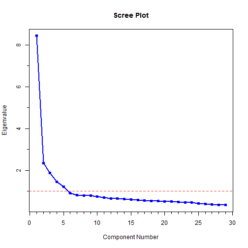

## How many factors?

- The maximal number of factors is the number of original variables Eigenvalue>1
- "Elbow" in the Scree plot
- Cumulative variance explained

## Step 5. Interpret the factors and Consider rotation of factors (technical but useful)

Rotated Factors

All PCA factors available with Rotation varimax (values less than 0.4 are not shown)

|  | Component 1 | Component 2 | Component 3 | Component 4 | Component 5 | Component 6 | Component 7 | Component 8 | Component 9 | Component 10 | Component 11 | Component 12 | Component 13 | Component 14 | Component 15 | Component 16 | Component 17 | Component 18 | Component 19 | Component 20 | Component 21 | Component 22 | Component 23 | Component 24 | Component 25 | Component 26 | Component 27 | Component 28 | Component 29 |
| --- | --- | --- | --- | --- | --- | --- | --- | --- | --- | --- | --- | --- | --- | --- | --- | --- | --- | --- | --- | --- | --- | --- | --- | --- | --- | --- | --- | --- | --- |
| Q1_1_When buying a boat, I do a lot of shopping around and visit multiple dealers |  |  |  |  | 0.965 |  |  |  |  |  |  |  |  |  |  |  |  |  |  |  |  |  |  |  |  |  |  |  |  |
| Q1_2_When buying a boat, getting the lowest price is more important than the boat brand |  |  |  |  |  |  |  |  |  |  |  |  |  | 0.963 |  |  |  |  |  |  |  |  |  |  |  |  |  |  |  |
| Q1_3_The brand of boat I buy says a lot about who I am |  |  |  |  |  |  |  |  |  |  |  |  |  |  |  |  |  |  |  | 0.862 |  |  |  |  |  |  |  |  |  |
| Q1_4_I only consider buying a boat from a reputable brand |  |  |  | 0.952 |  |  |  |  |  |  |  |  |  |  |  |  |  |  |  |  |  |  |  |  |  |  |  |  |  |
| Q1_5_I am willing to pay a premium for a brand with a reputation for high quality |  |  |  |  |  |  |  |  |  | 0.897 |  |  |  |  |  |  |  |  |  |  |  |  |  |  |  |  |  |  |  |
| Q1_6_Owning a boat is a way of rewarding myself for my hard work |  |  |  |  |  |  |  |  |  |  |  |  |  |  |  |  |  |  |  |  |  |  |  | 0.870 |  |  |  |  |  |
| Q1_7_Owning a boat gives me a sense of achievement |  |  |  |  |  |  |  |  |  |  |  |  |  |  |  |  |  |  |  |  |  |  | 0.864 |  |  |  |  |  |  |
| Q1_8_When buying a boat, functionality is more important than style |  |  |  |  |  |  |  |  |  |  |  |  | 0.981 |  |  |  |  |  |  |  |  |  |  |  |  |  |  |  |  |
| Q1_9_I see my boat as a status symbol |  |  |  |  |  |  |  |  |  |  |  |  |  |  |  |  |  | 0.863 |  |  |  |  |  |  |  |  |  |  |  |
| Q1_10_When buying a boat, I rely more on expert opinion than my own (e.g. consumer reports, salespeople) |  |  |  |  |  |  |  |  | 0.981 |  |  |  |  |  |  |  |  |  |  |  |  |  |  |  |  |  |  |  |  |
| Q1_11_I tend to perform minor boat repairs and maintenance on my own |  | 0.968 |  |  |  |  |  |  |  |  |  |  |  |  |  |  |  |  |  |  |  |  |  |  |  |  |  |  |  |
| Q1_12_When it comes to boating, I tend to prefer a basic boat with little to no frills |  |  |  |  |  |  |  |  |  |  |  | 0.959 |  |  |  |  |  |  |  |  |  |  |  |  |  |  |  |  |  |
| Q1_13_When buying a boat, I tend to buy the latest and greatest |  |  |  |  |  |  |  |  |  |  |  |  |  |  |  |  |  |  |  |  |  |  |  |  |  | 0.843 |  |  |  |
| Q1_14_When buying accessories for my boat, I tend to buy the latest and greatest |  |  |  |  |  |  |  |  |  |  |  |  |  |  |  |  |  |  |  |  |  |  |  |  |  |  | 0.840 |  |  |
| Q1_15_I am serious about the technology on my boat |  |  |  |  |  |  |  |  |  |  |  |  |  |  |  |  |  |  |  |  |  | 0.870 |  |  |  |  |  |  |  |
| Q1_16_People tend to come to me for advice about boating |  |  |  |  |  |  |  |  |  |  |  |  |  |  |  |  |  |  |  |  |  |  |  |  |  |  |  | 0.832 |  |
| Q1_17_I consider myself more knowledgeable about boating than the rest of my boating peers |  |  |  |  |  |  |  |  |  |  | 0.868 |  |  |  |  |  |  |  |  |  |  |  |  |  |  |  |  |  |  |
| Q1_18_Boating gives me a feeling of adventure |  |  |  |  |  |  |  |  |  |  |  |  |  |  |  |  |  |  |  |  |  |  |  |  | 0.880 |  |  |  |  |
| Q1_19_Boating allows me to experience nature |  |  |  |  |  |  | 0.917 |  |  |  |  |  |  |  |  |  |  |  |  |  |  |  |  |  |  |  |  |  |  |
| Q1_20_When not on my boat, I often find myself doing boating related activities |  |  |  |  |  |  |  |  |  |  |  |  |  |  |  |  |  |  |  |  | 0.863 |  |  |  |  |  |  |  |  |
| Q1_21_Boating helps me escape from everyday life and relax |  |  |  |  |  |  |  |  |  |  |  |  |  |  | 0.904 |  |  |  |  |  |  |  |  |  |  |  |  |  |  |
| Q1_22_Boating helps me stay active |  |  |  |  |  |  |  |  |  |  |  |  |  |  |  |  |  |  | 0.889 |  |  |  |  |  |  |  |  |  |  |
| Q1_23_Boating allows me to excel in the sports that I am passionate about (e.g. fishing, racing, water sports) | 0.913 |  |  |  |  |  |  |  |  |  |  |  |  |  |  |  |  |  |  |  |  |  |  |  |  |  |  |  |  |
| Q1_24_Boating gives me an outlet to socialize with family and/or friends |  |  |  |  |  | 0.919 |  |  |  |  |  |  |  |  |  |  |  |  |  |  |  |  |  |  |  |  |  |  |  |
| Q1_25_Being in charge of my boat is very important to me |  |  |  |  |  |  |  |  |  |  |  |  |  |  |  |  | 0.885 |  |  |  |  |  |  |  |  |  |  |  |  |
| Q1_26_Having a powerful boat is what is most important to me |  |  |  |  |  |  |  | 0.877 |  |  |  |  |  |  |  |  |  |  |  |  |  |  |  |  |  |  |  |  |  |
| Q1_27_Boating is the number one thing I do with my spare time |  |  |  |  |  |  |  |  |  |  |  |  |  |  |  | 0.864 |  |  |  |  |  |  |  |  |  |  |  |  |  |
| Q1_28_Boating is my true passion in life |  |  |  |  |  |  |  |  |  |  |  |  |  |  |  |  |  |  |  |  |  |  |  |  |  |  |  |  | 0.827 |
| Q1_29_Boating is one of many things I do in my spare time |  |  | 0.952 |  |  |  |  |  |  |  |  |  |  |  |  |  |  |  |  |  |  |  |  |  |  |  |  |  |  |

## What Factor Loads "Look Good"? Three Quality Criteria

1. For each factor (column) only a few loadings are large (in absolute value)
2. For each initial variable (row) only a few loadings are large (in absolute value)
3. Any pair of factors (columns) should have different "patterns" of loading

## Step 6. Save factor scores for subsequent analyses

Sample Data described using the selected Factors: Boating Company

|  | Derived Variable (Factor) 1 | Derived Variable (Factor) 2 | Derived Variable (Factor) 3 | Derived Variable (Factor) 4 | Derived Variable (Factor) 5 |
| --- | --- | --- | --- | --- | --- |
| 1 | 0.3 | 0.6 | -3.5 | 1.1 | 1.1 |
| 2 | 0.7 | 0.3 | 1.1 | -0.6 | 0.9 |
| 3 | -0.3 | 0.5 | 1.1 | -0.3 | -0.3 |
| 4 | -0.2 | -2.6 | 1.2 | -0.3 | -0.1 |
| 5 | 0.4 | -1.5 | 1.5 | -0.2 | 0.0 |

## Using the Factor Scores: Pereptual Maps

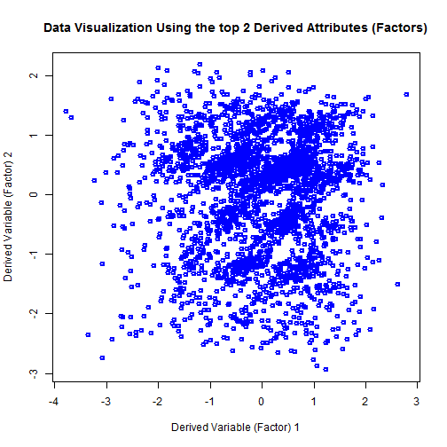

## Factor Analysis: Key (Technical) Notions

1. Correlation
2. Variance explained (eigenvalues)
3. Scree plot
4. Varimax rotation
5. Factor Loadings ("components")
6. Factor scores

## Next Class: Cluster Analysis for Segmentation